# data_modeling

Fazle Rabbi

October 25, 2015

The packages that will be used for modeling are:

```r
library(rpart)          # Build decision tree model with rpart().
library(randomForest)   # Build model with randomForest().
```

```r
library(ada)            # Build boosted trees model with ada().
library(rattle)         # Display tree model with fancyRpartPlot().
library(ROCR)           # Use prediction() for evaluation.
library(party)          # Build conditional tree models with ctree() and cforest().
library(ggplot2)        # Display evaluations.
```

## Step 4: Getting Started - Load the Dataset

In data preparation we saved the weather dataset, load it.

```r
(load("weather_151025.RData"))
```

```
##  [1] "ds"     "dsname" "dspath" "dsdate" "target" "risk"   "id"
##  [8] "ignore" "vars"   "nobs"   "omit"   "inputi" "inputc" "numi"
## [15] "numc"   "cati"   "catc"
```

```r
dsname
```

```
## [1] "weather"
```

```r
dspath
```

```
## [1] "http://rattle.togaware.com/weather.csv"
```

```r
dsdate
```

```
## [1] "_151025"
```

```r
dim(ds)
```

```
## [1] 366  24
```

```r
id
```

```
## [1] "date"     "location"
```

```r
target
```

```
## [1] "rain_tomorrow"
```

```r
risk
```

```
## [1] "risk_mm"
```

```r
ignore
```

```
## [1] "date"         "location"     "risk_mm"      "temp_3pm"
## [5] "pressure_9am" "temp_9am"
```

```r
vars
```

```
##  [1] "min_temp"        "max_temp"        "rainfall"
##  [4] "evaporation"     "sunshine"        "wind_gust_dir"
##  [7] "wind_gust_speed" "wind_dir_9am"    "wind_dir_3pm"
## [10] "wind_speed_9am"  "wind_speed_3pm"  "humidity_9am"
## [13] "humidity_3pm"    "pressure_3pm"    "cloud_9am"
## [16] "cloud_3pm"       "rain_today"      "rain_tomorrow"
```

## Step 4: Prepare - Formula to Describe the Goal

Predict rain_tomorrow from all other variables.

```r
(form <- formula(paste(target, "~ .")))  # target based on all other variables
```

```
## rain_tomorrow ~ .
```

## Step 4: Prepare - Training and Testing Datasets

Training, testing and validation datasets. First we initiate a random seed and report that seed so that the experiment can be repeated if necessary.

```r
(seed <- sample(1:1000000, 1))
```

```
## [1] 867296
```

```r
seed <- 123
set.seed(seed)
```

Next we partition into training (70% random sample) and testing dataset.

```r
length(train <- sample(nobs, 0.7*nobs))
```

```
## [1] 256
```

```r
length(test  <- setdiff(seq_len(nobs), train))
```

```
## [1] 110
```

The error rate calculated on testing dataset is closer to what we will obtain in general when we use the model. We also record the actual outcomes and the risks.

```r
actual.train <- ds[train, target]
actual <- ds[test, target]
risks <- ds[test, risk]
```

## Step 5: Build - Decision Tree

We build rpart() decision tree.

```r
ctrl <- rpart.control(maxdepth=3)
system.time(model <- m.rp <- rpart(form, ds[train, vars], control=ctrl))
```

```
##    user  system elapsed
##    0.02    0.00    0.01
```

```r
model
```

```
## n= 256
##
## node), split, n, loss, yval, (yprob)
##       * denotes terminal node
##
##  1) root 256 43 No (0.8320312 0.1679688)
##    2) humidity_3pm< 73.5 243 32 No (0.8683128 0.1316872)
##      4) pressure_3pm>=1010.25 206 16 No (0.9223301 0.0776699) *
##      5) pressure_3pm< 1010.25 37 16 No (0.5675676 0.4324324)
##       10) sunshine>=8.85 16  1 No (0.9375000 0.0625000) *
##       11) sunshine< 8.85 21  6 Yes (0.2857143 0.7142857) *
##    3) humidity_3pm>=73.5 13  2 Yes (0.1538462 0.8461538) *
```

[figure not shown]

```r
mtype <- "rpart" # Record the type of the model for later use.

library(rpart.plot)
library(RColorBrewer)

fancyRpartPlot(model)
```

## Step 6: Evaluate - Training Accuracy and AUC

Use the model to predict the class of the observations of the training dataset.

```r
head(cl <- predict(model, ds[train, vars], type="class"))
```

```
## 106 288 149 321 341  17
##  No  No  No  No Yes Yes
## Levels: No Yes
```

Then compare with the actual class of the training dataset.

```r
head(actual.train)
```

```
## [1] No  No  No  No  Yes Yes
## Levels: No Yes
```

We can calculate the overall accuracy over the training dataset, as simply the sum of the number of times the prediction agrees with the actual class, divided by the size of the training dataset.

```r
(acc <- sum(cl == actual.train, na.rm=TRUE)/length(actual.train))
```

```
## [1] 0.9023438
```

```r
(err <- sum(cl != actual.train, na.rm=TRUE)/length(actual.train))
```

```
## [1] 0.09765625
```

The model has overall error rate of 10%.

The area under the so-called ROC curve can also be calculated using ROCR.

```r
pr <- predict(model, ds[train, vars], type="prob")[,2]
pred <- prediction(pr, ds[train, target])
(atr <- attr(performance(pred, "auc"), "y.values")[[1]])
```

```
## [1] 0.7882411
```

As we have noted though, performing any evaluation on the training dataset provides a biased estimate of the actual performance. We must evaluate on testing dataset.

```r
cl <- predict(model, ds[test, vars], type="class")
(acc <- sum(cl == actual, na.rm=TRUE)/length(actual))
```

```
## [1] 0.8363636
```

```r
(err <- sum(cl != actual, na.rm=TRUE)/length(actual))
```

```
## [1] 0.1636364
```

The overall accuracy is 84%. The overall error rate is 16%.

```r
pr <- predict(model, ds[test, vars], type="prob")[,2]
pred <- prediction(pr, ds[test, target])
(ate <- attr(performance(pred, "auc"), "y.values")[[1]])
```

```
## [1] 0.6826587
```

The AUC is 68%. All of these performance measures are less than what we found on the trianing dataset, as we should expect.

## Step 6: Evaluate - Confusion Matrix

First for the training set.

```r
cl <- predict(model, ds[train, vars], type="class")
round(100*table(actual.train, cl, dnn=c("Actual", "Predicted"))/length(actual.train))
```

```
##       Predicted
## Actual No Yes
##    No  80   3
##    Yes  7  10
```

Then for the testing set.

```r
cl <- predict(model, ds[test, vars], type="class")
round(100*table(actual, cl, dnn=c("Actual", "Predicted"))/length(actual))
```

```
##       Predicted
## Actual No Yes
##    No  74   5
##    Yes 11  10
```

A **confusion matrix** is also called an error matrix or contingency table. The problem with calling them an error matrix is that not every cell in the table reports an error. The diagonals record the accuracy. Thus a quick look by a new data scientist might lead them to think the errors are high, based on the diagonals. The potential for this confusion is a good reason to call them something other than an error matrix.

## Step 6: Evaluate - Risk Chart

A risk chart is also known as an accumulative performance plot.

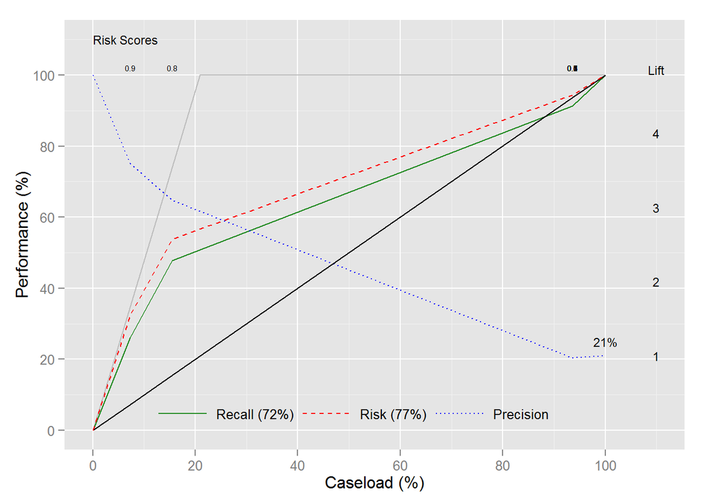

```r
riskchart(pr, ds[test, target], ds[test, risk])
```

## Step 7: Experiment - Framework

We can repeat the modelling multiple times, randomly selecting different datasets for training, to get an estimate of the actual expected performance and variation we see in the performance.

```r
source("experi.R")
```

```
## AUC 0.3.0
##
##
```

```r
n <- 10

# Run with rpart
ex.rp <- experi(form, ds[vars], dsname, target, "rpart", "1", n=n, keep=TRUE)
# Run with randomForest
ex.rf <- experi(form, ds[vars], dsname, target, "randomForest", "500", n=n, keep=TRUE,
                control=list(na.action=na.omit))
# Run with ada
ex.ad <- experi(form, ds[vars], dsname, target, "ada", "50", n=n, keep=TRUE)

# Run with ctree
ex.ct <- experi(form, ds[vars], dsname, target, "ctree", "1", n=n, keep=TRUE)

# Run with cforest
# Generates: error code 1 from Lapack routine 'dgesdd'
# ex.cf <- experi(form, ds[vars], dsname, target, "cforest", "500", n=n, keep=TRUE)

# Do other also, lm, svm, C5.0, J48 etc.

# Result
results <- rbind(ex.rp, ex.rf, ex.ad, ex.ct)
rownames(results) <- results$modeller
results$modeller <- NULL
results
```

```
##                   auc auc.sd cor cor.sd str str.sd  acc acc.sd  n user
## rpart_1          0.72   0.08  NA     NA  NA     NA 0.81   0.02 10 0.77
## randomForest_500 0.84   0.08  NA     NA  NA     NA 0.77   0.04 10 1.79
## ada_50           0.82   0.02  NA     NA  NA     NA 0.84   0.03 10 9.46
## ctree_1          0.75   0.04  NA     NA  NA     NA 0.83   0.04 10 0.59
##                  elapsed
## rpart_1             0.82
## randomForest_500    1.84
## ada_50              9.50
## ctree_1             0.66
```

## Step 7: Experiment - RiskChart Decision Tree

The result of the call to experi() includes the attributes pr and test if the number of classes is two and keep=TRUE. We can thus use this to generate a risk chart for the last of the models built in the experiment.

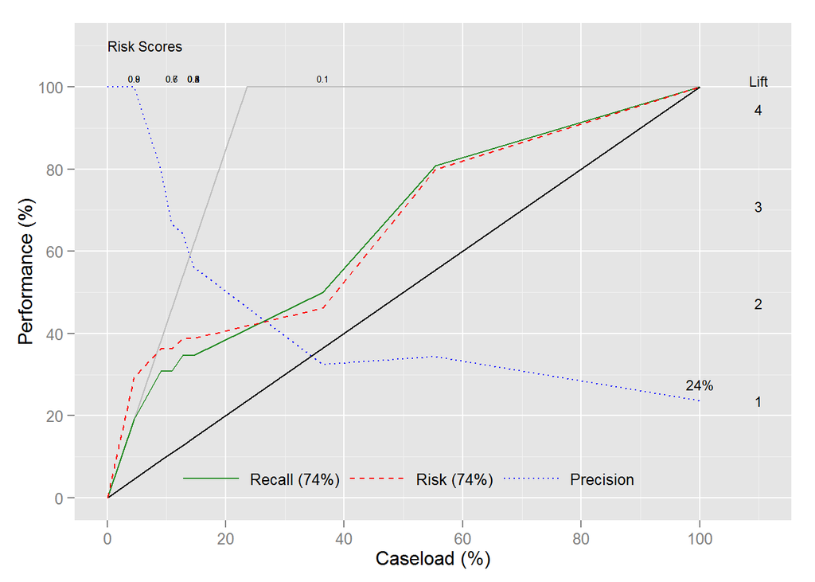

```r
ex <- ex.rp
pr <- attr(ex, "pr")
test <- attr(ex, "test")
riskchart(pr, ds[test, target], ds[test, risk])
```

## Step 7: Experiment - RiskChart Random Forest

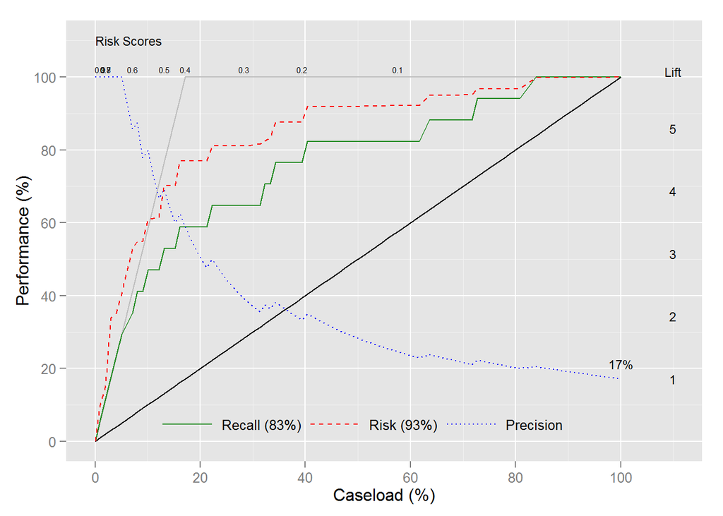

```r
ex <- ex.rf
pr <- attr(ex, "pr")
test <- attr(ex, "test")
riskchart(pr, ds[test, target], ds[test, risk])
```

## Step 7: Experiment - RiskChart Ada Boost

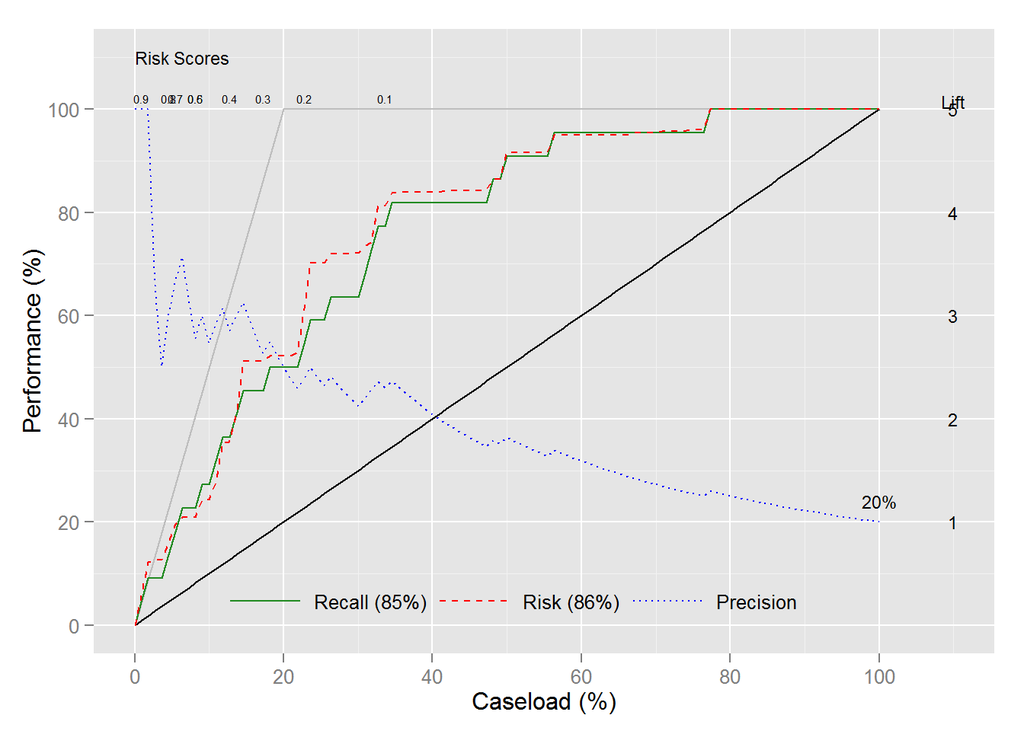

```r
ex <- ex.ad
pr <- attr(ex, "pr")
test <- attr(ex, "test")
riskchart(pr, ds[test, target], ds[test, risk])
```

## Step 7: Experiment - RiskChart Conditional Tree

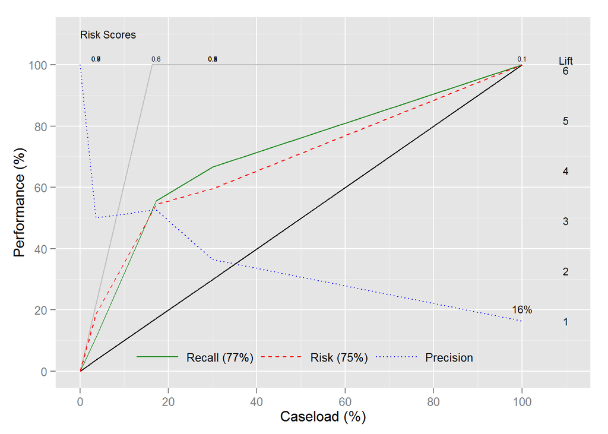

```r
ex <- ex.ct
pr <- attr(ex, "pr")
test <- attr(ex, "test")
riskchart(pr, ds[test, target], ds[test, risk])
```

## Step 8: Finish Up - Save Model

We save the model, together with the dataset and other variables, into a binary R file.

```r
dname <- "models"
if (! file.exists(dname)) dir.create(dname)
time.stamp <- format(Sys.time(), "%Y%m%d_%H%M%S")
fstem <- paste(dsname, mtype, time.stamp, sep="_")
(fname <- file.path(dname, sprintf("%s.RData", fstem)))
```

```
## [1] "models/weather_rpart_20151030_214407.RData"
```

```r
save(ds, dsname, vars, target, risk, ignore,
     form, nobs, seed, train, test, model, mtype, pr,
     file=fname)
```